# Risk Factor Analysis

## Outcome Variable

**Outcome Variable:** y_rate_len

## Predictor Variables

**Intervention Variable:** trth2o

**Adjustment Set:**

unadjusted

## Stratifying Variables

The analysis was stratified on these variable(s):

- agecat
- studyid
- country

## Data Summary

| agecat | studyid | country | trth2o | n_cell | n |
| --- | --- | --- | --- | --- | --- |
| 0-3 months | ki0047075b-MAL-ED | BANGLADESH | 0 | 2 | 134 |
| 0-3 months | ki0047075b-MAL-ED | BANGLADESH | 1 | 132 | 134 |
| 0-3 months | ki1017093b-PROVIDE | BANGLADESH | 0 | 620 | 634 |
| 0-3 months | ki1017093b-PROVIDE | BANGLADESH | 1 | 14 | 634 |
| 0-3 months | ki1017093c-NIH-Crypto | BANGLADESH | 0 | 319 | 720 |
| 0-3 months | ki1017093c-NIH-Crypto | BANGLADESH | 1 | 401 | 720 |
| 0-3 months | ki0047075b-MAL-ED | BRAZIL | 0 | 72 | 84 |
| 0-3 months | ki0047075b-MAL-ED | BRAZIL | 1 | 12 | 84 |
| 0-3 months | ki0047075b-MAL-ED | INDIA | 0 | 4 | 6 |
| 0-3 months | ki0047075b-MAL-ED | INDIA | 1 | 2 | 6 |
| 0-3 months | ki1000108-CMC-V-BCS-2002 | INDIA | 1 | 25 | 25 |
| 0-3 months | ki1000108-IRC | INDIA | 1 | 118 | 118 |
| 0-3 months | ki0047075b-MAL-ED | NEPAL | 0 | 12 | 63 |
| 0-3 months | ki0047075b-MAL-ED | NEPAL | 1 | 51 | 63 |
| 0-3 months | ki0047075b-MAL-ED | PERU | 0 | 9 | 46 |
| 0-3 months | ki0047075b-MAL-ED | PERU | 1 | 37 | 46 |
| 0-3 months | ki0047075b-MAL-ED | SOUTH AFRICA | 0 | 9 | 10 |
| 0-3 months | ki0047075b-MAL-ED | SOUTH AFRICA | 1 | 1 | 10 |
| 0-3 months | ki0047075b-MAL-ED | TANZANIA, UNITED REPUBLIC OF | 0 | 32 | 38 |
| 0-3 months | ki0047075b-MAL-ED | TANZANIA, UNITED REPUBLIC OF | 1 | 6 | 38 |
| 3-6 months | ki0047075b-MAL-ED | BANGLADESH | 0 | 2 | 132 |
| 3-6 months | ki0047075b-MAL-ED | BANGLADESH | 1 | 130 | 132 |
| 3-6 months | ki1017093b-PROVIDE | BANGLADESH | 0 | 561 | 574 |
| 3-6 months | ki1017093b-PROVIDE | BANGLADESH | 1 | 13 | 574 |
| 3-6 months | ki1017093c-NIH-Crypto | BANGLADESH | 0 | 313 | 695 |
| 3-6 months | ki1017093c-NIH-Crypto | BANGLADESH | 1 | 382 | 695 |
| 3-6 months | ki0047075b-MAL-ED | BRAZIL | 0 | 90 | 103 |
| 3-6 months | ki0047075b-MAL-ED | BRAZIL | 1 | 13 | 103 |
| 3-6 months | ki0047075b-MAL-ED | INDIA | 0 | 4 | 7 |
| 3-6 months | ki0047075b-MAL-ED | INDIA | 1 | 3 | 7 |

[output cut: 56 more lines]

The following strata were considered:

- agecat: 0-3 months, studyid: ki0047075b-MAL-ED, country: BANGLADESH
- agecat: 0-3 months, studyid: ki0047075b-MAL-ED, country: BRAZIL
- agecat: 0-3 months, studyid: ki0047075b-MAL-ED, country: INDIA
- agecat: 0-3 months, studyid: ki0047075b-MAL-ED, country: NEPAL
- agecat: 0-3 months, studyid: ki0047075b-MAL-ED, country: PERU
- agecat: 0-3 months, studyid: ki0047075b-MAL-ED, country: SOUTH AFRICA
- agecat: 0-3 months, studyid: ki0047075b-MAL-ED, country: TANZANIA, UNITED REPUBLIC OF
- agecat: 0-3 months, studyid: ki1000108-CMC-V-BCS-2002, country: INDIA
- agecat: 0-3 months, studyid: ki1000108-IRC, country: INDIA
- agecat: 0-3 months, studyid: ki1017093b-PROVIDE, country: BANGLADESH
- agecat: 0-3 months, studyid: ki1017093c-NIH-Crypto, country: BANGLADESH
- agecat: 12-24 months, studyid: ki0047075b-MAL-ED, country: BANGLADESH
- agecat: 12-24 months, studyid: ki0047075b-MAL-ED, country: BRAZIL
- agecat: 12-24 months, studyid: ki0047075b-MAL-ED, country: INDIA
- agecat: 12-24 months, studyid: ki0047075b-MAL-ED, country: NEPAL
- agecat: 12-24 months, studyid: ki0047075b-MAL-ED, country: PERU
- agecat: 12-24 months, studyid: ki0047075b-MAL-ED, country: SOUTH AFRICA
- agecat: 12-24 months, studyid: ki0047075b-MAL-ED, country: TANZANIA, UNITED REPUBLIC OF
- agecat: 12-24 months, studyid: ki1000108-CMC-V-BCS-2002, country: INDIA
- agecat: 12-24 months, studyid: ki1000108-IRC, country: INDIA
- agecat: 12-24 months, studyid: ki1017093b-PROVIDE, country: BANGLADESH
- agecat: 12-24 months, studyid: ki1017093c-NIH-Crypto, country: BANGLADESH
- agecat: 12-24 months, studyid: ki1113344-GMS-Nepal, country: NEPAL
- agecat: 3-6 months, studyid: ki0047075b-MAL-ED, country: BANGLADESH
- agecat: 3-6 months, studyid: ki0047075b-MAL-ED, country: BRAZIL
- agecat: 3-6 months, studyid: ki0047075b-MAL-ED, country: INDIA
- agecat: 3-6 months, studyid: ki0047075b-MAL-ED, country: NEPAL
- agecat: 3-6 months, studyid: ki0047075b-MAL-ED, country: PERU
- agecat: 3-6 months, studyid: ki0047075b-MAL-ED, country: SOUTH AFRICA
- agecat: 3-6 months, studyid: ki0047075b-MAL-ED, country: TANZANIA, UNITED REPUBLIC OF
- agecat: 3-6 months, studyid: ki1000108-CMC-V-BCS-2002, country: INDIA
- agecat: 3-6 months, studyid: ki1000108-IRC, country: INDIA
- agecat: 3-6 months, studyid: ki1017093b-PROVIDE, country: BANGLADESH
- agecat: 3-6 months, studyid: ki1017093c-NIH-Crypto, country: BANGLADESH
- agecat: 3-6 months, studyid: ki1113344-GMS-Nepal, country: NEPAL
- agecat: 6-12 months, studyid: ki0047075b-MAL-ED, country: BANGLADESH
- agecat: 6-12 months, studyid: ki0047075b-MAL-ED, country: BRAZIL
- agecat: 6-12 months, studyid: ki0047075b-MAL-ED, country: INDIA
- agecat: 6-12 months, studyid: ki0047075b-MAL-ED, country: NEPAL
- agecat: 6-12 months, studyid: ki0047075b-MAL-ED, country: PERU
- agecat: 6-12 months, studyid: ki0047075b-MAL-ED, country: SOUTH AFRICA
- agecat: 6-12 months, studyid: ki0047075b-MAL-ED, country: TANZANIA, UNITED REPUBLIC OF
- agecat: 6-12 months, studyid: ki1000108-CMC-V-BCS-2002, country: INDIA
- agecat: 6-12 months, studyid: ki1000108-IRC, country: INDIA
- agecat: 6-12 months, studyid: ki1017093b-PROVIDE, country: BANGLADESH
- agecat: 6-12 months, studyid: ki1017093c-NIH-Crypto, country: BANGLADESH
- agecat: 6-12 months, studyid: ki1113344-GMS-Nepal, country: NEPAL

### Dropped Strata

Some strata were dropped due to rare outcomes:

- agecat: 0-3 months, studyid: ki0047075b-MAL-ED, country: BANGLADESH
- agecat: 0-3 months, studyid: ki0047075b-MAL-ED, country: INDIA
- agecat: 0-3 months, studyid: ki0047075b-MAL-ED, country: SOUTH AFRICA
- agecat: 3-6 months, studyid: ki0047075b-MAL-ED, country: BANGLADESH
- agecat: 3-6 months, studyid: ki0047075b-MAL-ED, country: INDIA
- agecat: 3-6 months, studyid: ki1113344-GMS-Nepal, country: NEPAL
- agecat: 3-6 months, studyid: ki0047075b-MAL-ED, country: SOUTH AFRICA
- agecat: 6-12 months, studyid: ki0047075b-MAL-ED, country: BANGLADESH
- agecat: 6-12 months, studyid: ki0047075b-MAL-ED, country: INDIA
- agecat: 6-12 months, studyid: ki1113344-GMS-Nepal, country: NEPAL
- agecat: 6-12 months, studyid: ki0047075b-MAL-ED, country: SOUTH AFRICA
- agecat: 12-24 months, studyid: ki0047075b-MAL-ED, country: BANGLADESH
- agecat: 12-24 months, studyid: ki0047075b-MAL-ED, country: INDIA
- agecat: 12-24 months, studyid: ki1113344-GMS-Nepal, country: NEPAL
- agecat: 12-24 months, studyid: ki0047075b-MAL-ED, country: SOUTH AFRICA

## Methods Detail

We’re interested in the causal parameters $E[Y_a]$ for all values of $a \in \mathcal{A}$. These parameters represent the mean outcome if, possibly contrary to fact, we intervened to set all units to have $A=a$. Under the randomization and positivity assumptions, these are identified by the statistical parameters $\psi_a=E_W[E_{Y|A,W}(Y|A=a,W)]$. In addition, we’re interested in the mean of $Y$, $E[Y]$ under no intervention (the observed mean). We will estimate these parameters by using SuperLearner to fit the relevant likelihood factors – $E_{Y|A,W}(Y|A=a,W)$ and $p(A=a|W)$, and then updating our likelihood fit using a joint TMLE.

For unadjusted analyses ($W=\{\}$), initial likelihoods were estimated using Lrnr_glm to estimate the simple $E(Y|A)$ and Lrnr_mean to estimate $p(A)$. For adjusted analyses, a small library containing Lrnr_glmnet, Lrnr_xgboost, and Lrnr_mean was used.

Having estimated these parameters, we will then use the delta method to estimate relative risks and attributable risks relative to a prespecified baseline level of $A$.

[output not shown]

[output cut: 801 more lines]

[output not shown]

# Results Detail

## Results Plots

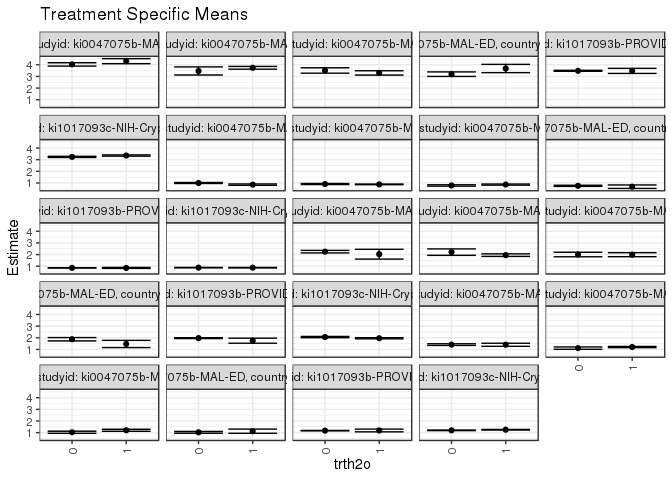

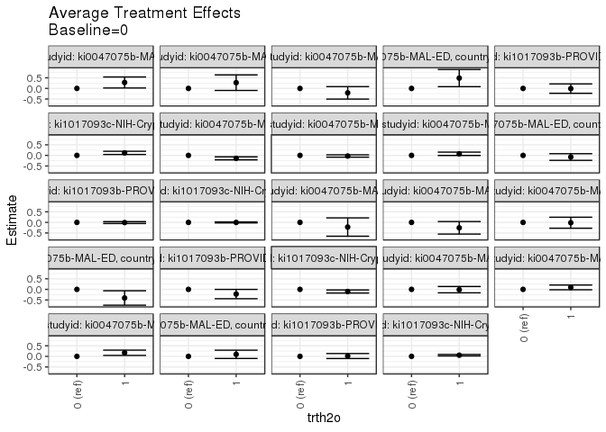

## Results Table

### Parameter: TSM

| agecat | studyid | country | intervention_level | baseline_level | estimate | ci_lower | ci_upper |
| --- | --- | --- | --- | --- | --- | --- | --- |
| 0-3 months | ki0047075b-MAL-ED | BRAZIL | 0 | NA | 4.0315373 | 3.8866194 | 4.1764552 |
| 0-3 months | ki0047075b-MAL-ED | BRAZIL | 1 | NA | 4.3116371 | 4.0953860 | 4.5278881 |
| 0-3 months | ki0047075b-MAL-ED | NEPAL | 0 | NA | 3.4705160 | 3.1223410 | 3.8186909 |
| 0-3 months | ki0047075b-MAL-ED | NEPAL | 1 | NA | 3.7419203 | 3.6244735 | 3.8593671 |
| 0-3 months | ki0047075b-MAL-ED | PERU | 0 | NA | 3.5110628 | 3.2812212 | 3.7409044 |
| 0-3 months | ki0047075b-MAL-ED | PERU | 1 | NA | 3.3018257 | 3.1177732 | 3.4858781 |
| 0-3 months | ki0047075b-MAL-ED | TANZANIA, UNITED REPUBLIC OF | 0 | NA | 3.1945125 | 2.9985906 | 3.3904344 |
| 0-3 months | ki0047075b-MAL-ED | TANZANIA, UNITED REPUBLIC OF | 1 | NA | 3.6820549 | 3.3277337 | 4.0363762 |
| 0-3 months | ki1017093b-PROVIDE | BANGLADESH | 0 | NA | 3.4828580 | 3.4430947 | 3.5226212 |
| 0-3 months | ki1017093b-PROVIDE | BANGLADESH | 1 | NA | 3.4743728 | 3.2559422 | 3.6928033 |
| 0-3 months | ki1017093c-NIH-Crypto | BANGLADESH | 0 | NA | 3.2366914 | 3.1857466 | 3.2876362 |
| 0-3 months | ki1017093c-NIH-Crypto | BANGLADESH | 1 | NA | 3.3555079 | 3.3007310 | 3.4102848 |
| 3-6 months | ki0047075b-MAL-ED | BRAZIL | 0 | NA | 2.2506162 | 2.1421813 | 2.3590511 |
| 3-6 months | ki0047075b-MAL-ED | BRAZIL | 1 | NA | 2.0298802 | 1.6110471 | 2.4487134 |
| 3-6 months | ki0047075b-MAL-ED | NEPAL | 0 | NA | 2.2078155 | 1.9326594 | 2.4829717 |
| 3-6 months | ki0047075b-MAL-ED | NEPAL | 1 | NA | 1.9511972 | 1.8414583 | 2.0609362 |
| 3-6 months | ki0047075b-MAL-ED | PERU | 0 | NA | 2.0034011 | 1.8105150 | 2.1962872 |
| 3-6 months | ki0047075b-MAL-ED | PERU | 1 | NA | 1.9870567 | 1.8134152 | 2.1606981 |
| 3-6 months | ki0047075b-MAL-ED | TANZANIA, UNITED REPUBLIC OF | 0 | NA | 1.8739708 | 1.7296439 | 2.0182977 |
| 3-6 months | ki0047075b-MAL-ED | TANZANIA, UNITED REPUBLIC OF | 1 | NA | 1.4680425 | 1.1592662 | 1.7768187 |
| 3-6 months | ki1017093b-PROVIDE | BANGLADESH | 0 | NA | 1.9704556 | 1.9350359 | 2.0058752 |
| 3-6 months | ki1017093b-PROVIDE | BANGLADESH | 1 | NA | 1.7492376 | 1.5331023 | 1.9653728 |
| 3-6 months | ki1017093c-NIH-Crypto | BANGLADESH | 0 | NA | 2.0606804 | 2.0049186 | 2.1164422 |
| 3-6 months | ki1017093c-NIH-Crypto | BANGLADESH | 1 | NA | 1.9608276 | 1.9133116 | 2.0083436 |
| 6-12 months | ki0047075b-MAL-ED | BRAZIL | 0 | NA | 1.4145989 | 1.3420471 | 1.4871506 |
| 6-12 months | ki0047075b-MAL-ED | BRAZIL | 1 | NA | 1.4006411 | 1.2700723 | 1.5312099 |
| 6-12 months | ki0047075b-MAL-ED | NEPAL | 0 | NA | 1.1126970 | 1.0122938 | 1.2131001 |
| 6-12 months | ki0047075b-MAL-ED | NEPAL | 1 | NA | 1.2063823 | 1.1578111 | 1.2549534 |
| 6-12 months | ki0047075b-MAL-ED | PERU | 0 | NA | 1.0358110 | 0.9453826 | 1.1262394 |
| 6-12 months | ki0047075b-MAL-ED | PERU | 1 | NA | 1.2055967 | 1.1198796 | 1.2913137 |
| 6-12 months | ki0047075b-MAL-ED | TANZANIA, UNITED REPUBLIC OF | 0 | NA | 1.0300848 | 0.9545728 | 1.1055968 |
| 6-12 months | ki0047075b-MAL-ED | TANZANIA, UNITED REPUBLIC OF | 1 | NA | 1.1257413 | 0.9455595 | 1.3059231 |
| 6-12 months | ki1017093b-PROVIDE | BANGLADESH | 0 | NA | 1.1728170 | 1.1553172 | 1.1903167 |
| 6-12 months | ki1017093b-PROVIDE | BANGLADESH | 1 | NA | 1.1878781 | 1.0710907 | 1.3046656 |
| 6-12 months | ki1017093c-NIH-Crypto | BANGLADESH | 0 | NA | 1.1984302 | 1.1742337 | 1.2226267 |
| 6-12 months | ki1017093c-NIH-Crypto | BANGLADESH | 1 | NA | 1.2534382 | 1.2288553 | 1.2780210 |
| 12-24 months | ki0047075b-MAL-ED | BRAZIL | 0 | NA | 0.9946891 | 0.9529857 | 1.0363925 |
| 12-24 months | ki0047075b-MAL-ED | BRAZIL | 1 | NA | 0.8556806 | 0.7985217 | 0.9128395 |
| 12-24 months | ki0047075b-MAL-ED | NEPAL | 0 | NA | 0.9076558 | 0.8607696 | 0.9545421 |
| 12-24 months | ki0047075b-MAL-ED | NEPAL | 1 | NA | 0.8795024 | 0.8518125 | 0.9071924 |
| 12-24 months | ki0047075b-MAL-ED | PERU | 0 | NA | 0.7852420 | 0.7236124 | 0.8468717 |
| 12-24 months | ki0047075b-MAL-ED | PERU | 1 | NA | 0.8610919 | 0.8128258 | 0.9093581 |
| 12-24 months | ki0047075b-MAL-ED | TANZANIA, UNITED REPUBLIC OF | 0 | NA | 0.7555402 | 0.7065698 | 0.8045106 |
| 12-24 months | ki0047075b-MAL-ED | TANZANIA, UNITED REPUBLIC OF | 1 | NA | 0.6796135 | 0.5299671 | 0.8292599 |
| 12-24 months | ki1017093b-PROVIDE | BANGLADESH | 0 | NA | 0.8577536 | 0.8455099 | 0.8699974 |
| 12-24 months | ki1017093b-PROVIDE | BANGLADESH | 1 | NA | 0.8493548 | 0.8071068 | 0.8916027 |
| 12-24 months | ki1017093c-NIH-Crypto | BANGLADESH | 0 | NA | 0.8766531 | 0.8607365 | 0.8925697 |
| 12-24 months | ki1017093c-NIH-Crypto | BANGLADESH | 1 | NA | 0.8743080 | 0.8567758 | 0.8918402 |

### Parameter: E(Y)

| agecat | studyid | country | intervention_level | baseline_level | estimate | ci_lower | ci_upper |
| --- | --- | --- | --- | --- | --- | --- | --- |
| 0-3 months | ki0047075b-MAL-ED | BRAZIL | NA | NA | 4.0715516 | 3.9418270 | 4.2012761 |
| 0-3 months | ki0047075b-MAL-ED | NEPAL | NA | NA | 3.6902242 | 3.5713067 | 3.8091418 |
| 0-3 months | ki0047075b-MAL-ED | PERU | NA | NA | 3.3427634 | 3.1861528 | 3.4993739 |
| 0-3 months | ki0047075b-MAL-ED | TANZANIA, UNITED REPUBLIC OF | NA | NA | 3.2714929 | 3.0881028 | 3.4548830 |
| 0-3 months | ki1017093b-PROVIDE | BANGLADESH | NA | NA | 3.4826706 | 3.4434873 | 3.5218539 |
| 0-3 months | ki1017093c-NIH-Crypto | BANGLADESH | NA | NA | 3.3028656 | 3.2646714 | 3.3410598 |
| 3-6 months | ki0047075b-MAL-ED | BRAZIL | NA | NA | 2.2227563 | 2.1133297 | 2.3321829 |
| 3-6 months | ki0047075b-MAL-ED | NEPAL | NA | NA | 1.9950101 | 1.8904604 | 2.0995599 |
| 3-6 months | ki0047075b-MAL-ED | PERU | NA | NA | 1.9903923 | 1.8466790 | 2.1341055 |
| 3-6 months | ki0047075b-MAL-ED | TANZANIA, UNITED REPUBLIC OF | NA | NA | 1.8159811 | 1.6776334 | 1.9543288 |
| 3-6 months | ki1017093b-PROVIDE | BANGLADESH | NA | NA | 1.9654454 | 1.9303798 | 2.0005110 |
| 3-6 months | ki1017093c-NIH-Crypto | BANGLADESH | NA | NA | 2.0057973 | 1.9693775 | 2.0422170 |
| 6-12 months | ki0047075b-MAL-ED | BRAZIL | NA | NA | 1.4128372 | 1.3473294 | 1.4783450 |
| 6-12 months | ki0047075b-MAL-ED | NEPAL | NA | NA | 1.1905799 | 1.1461403 | 1.2350196 |
| 6-12 months | ki0047075b-MAL-ED | PERU | NA | NA | 1.1709466 | 1.0976676 | 1.2442255 |
| 6-12 months | ki0047075b-MAL-ED | TANZANIA, UNITED REPUBLIC OF | NA | NA | 1.0440833 | 0.9736537 | 1.1145130 |
| 6-12 months | ki1017093b-PROVIDE | BANGLADESH | NA | NA | 1.1731762 | 1.1558671 | 1.1904853 |
| 6-12 months | ki1017093c-NIH-Crypto | BANGLADESH | NA | NA | 1.2281313 | 1.2106849 | 1.2455776 |
| 12-24 months | ki0047075b-MAL-ED | BRAZIL | NA | NA | 0.9771443 | 0.9389322 | 1.0153564 |
| 12-24 months | ki0047075b-MAL-ED | NEPAL | NA | NA | 0.8842512 | 0.8598045 | 0.9086979 |
| 12-24 months | ki0047075b-MAL-ED | PERU | NA | NA | 0.8452899 | 0.8040289 | 0.8865508 |
| 12-24 months | ki0047075b-MAL-ED | TANZANIA, UNITED REPUBLIC OF | NA | NA | 0.7446935 | 0.6968915 | 0.7924955 |
| 12-24 months | ki1017093b-PROVIDE | BANGLADESH | NA | NA | 0.8575519 | 0.8455586 | 0.8695452 |
| 12-24 months | ki1017093c-NIH-Crypto | BANGLADESH | NA | NA | 0.8755729 | 0.8637860 | 0.8873598 |

### Parameter: ATE

| agecat | studyid | country | intervention_level | baseline_level | estimate | ci_lower | ci_upper |
| --- | --- | --- | --- | --- | --- | --- | --- |
| 0-3 months | ki0047075b-MAL-ED | BRAZIL | 0 | 0 | 0.0000000 | 0.0000000 | 0.0000000 |
| 0-3 months | ki0047075b-MAL-ED | BRAZIL | 1 | 0 | 0.2800998 | 0.0197813 | 0.5404183 |
| 0-3 months | ki0047075b-MAL-ED | NEPAL | 0 | 0 | 0.0000000 | 0.0000000 | 0.0000000 |
| 0-3 months | ki0047075b-MAL-ED | NEPAL | 1 | 0 | 0.2714044 | -0.0960457 | 0.6388544 |
| 0-3 months | ki0047075b-MAL-ED | PERU | 0 | 0 | 0.0000000 | 0.0000000 | 0.0000000 |
| 0-3 months | ki0047075b-MAL-ED | PERU | 1 | 0 | -0.2092371 | -0.5036900 | 0.0852157 |
| 0-3 months | ki0047075b-MAL-ED | TANZANIA, UNITED REPUBLIC OF | 0 | 0 | 0.0000000 | 0.0000000 | 0.0000000 |
| 0-3 months | ki0047075b-MAL-ED | TANZANIA, UNITED REPUBLIC OF | 1 | 0 | 0.4875424 | 0.0826610 | 0.8924238 |
| 0-3 months | ki1017093b-PROVIDE | BANGLADESH | 0 | 0 | 0.0000000 | 0.0000000 | 0.0000000 |
| 0-3 months | ki1017093b-PROVIDE | BANGLADESH | 1 | 0 | -0.0084852 | -0.2305055 | 0.2135351 |
| 0-3 months | ki1017093c-NIH-Crypto | BANGLADESH | 0 | 0 | 0.0000000 | 0.0000000 | 0.0000000 |
| 0-3 months | ki1017093c-NIH-Crypto | BANGLADESH | 1 | 0 | 0.1188165 | 0.0440109 | 0.1936221 |
| 3-6 months | ki0047075b-MAL-ED | BRAZIL | 0 | 0 | 0.0000000 | 0.0000000 | 0.0000000 |
| 3-6 months | ki0047075b-MAL-ED | BRAZIL | 1 | 0 | -0.2207360 | -0.6533782 | 0.2119063 |
| 3-6 months | ki0047075b-MAL-ED | NEPAL | 0 | 0 | 0.0000000 | 0.0000000 | 0.0000000 |
| 3-6 months | ki0047075b-MAL-ED | NEPAL | 1 | 0 | -0.2566183 | -0.5528505 | 0.0396140 |
| 3-6 months | ki0047075b-MAL-ED | PERU | 0 | 0 | 0.0000000 | 0.0000000 | 0.0000000 |
| 3-6 months | ki0047075b-MAL-ED | PERU | 1 | 0 | -0.0163444 | -0.2758756 | 0.2431867 |
| 3-6 months | ki0047075b-MAL-ED | TANZANIA, UNITED REPUBLIC OF | 0 | 0 | 0.0000000 | 0.0000000 | 0.0000000 |
| 3-6 months | ki0047075b-MAL-ED | TANZANIA, UNITED REPUBLIC OF | 1 | 0 | -0.4059284 | -0.7467700 | -0.0650868 |
| 3-6 months | ki1017093b-PROVIDE | BANGLADESH | 0 | 0 | 0.0000000 | 0.0000000 | 0.0000000 |
| 3-6 months | ki1017093b-PROVIDE | BANGLADESH | 1 | 0 | -0.2212180 | -0.4402363 | -0.0021997 |
| 3-6 months | ki1017093c-NIH-Crypto | BANGLADESH | 0 | 0 | 0.0000000 | 0.0000000 | 0.0000000 |
| 3-6 months | ki1017093c-NIH-Crypto | BANGLADESH | 1 | 0 | -0.0998528 | -0.1731136 | -0.0265920 |
| 6-12 months | ki0047075b-MAL-ED | BRAZIL | 0 | 0 | 0.0000000 | 0.0000000 | 0.0000000 |
| 6-12 months | ki0047075b-MAL-ED | BRAZIL | 1 | 0 | -0.0139577 | -0.1633296 | 0.1354141 |
| 6-12 months | ki0047075b-MAL-ED | NEPAL | 0 | 0 | 0.0000000 | 0.0000000 | 0.0000000 |
| 6-12 months | ki0047075b-MAL-ED | NEPAL | 1 | 0 | 0.0936853 | -0.0178492 | 0.2052198 |
| 6-12 months | ki0047075b-MAL-ED | PERU | 0 | 0 | 0.0000000 | 0.0000000 | 0.0000000 |
| 6-12 months | ki0047075b-MAL-ED | PERU | 1 | 0 | 0.1697857 | 0.0451875 | 0.2943839 |
| 6-12 months | ki0047075b-MAL-ED | TANZANIA, UNITED REPUBLIC OF | 0 | 0 | 0.0000000 | 0.0000000 | 0.0000000 |
| 6-12 months | ki0047075b-MAL-ED | TANZANIA, UNITED REPUBLIC OF | 1 | 0 | 0.0956564 | -0.0997087 | 0.2910216 |
| 6-12 months | ki1017093b-PROVIDE | BANGLADESH | 0 | 0 | 0.0000000 | 0.0000000 | 0.0000000 |
| 6-12 months | ki1017093b-PROVIDE | BANGLADESH | 1 | 0 | 0.0150612 | -0.1030301 | 0.1331524 |
| 6-12 months | ki1017093c-NIH-Crypto | BANGLADESH | 0 | 0 | 0.0000000 | 0.0000000 | 0.0000000 |
| 6-12 months | ki1017093c-NIH-Crypto | BANGLADESH | 1 | 0 | 0.0550080 | 0.0205146 | 0.0895013 |
| 12-24 months | ki0047075b-MAL-ED | BRAZIL | 0 | 0 | 0.0000000 | 0.0000000 | 0.0000000 |
| 12-24 months | ki0047075b-MAL-ED | BRAZIL | 1 | 0 | -0.1390085 | -0.2097637 | -0.0682532 |
| 12-24 months | ki0047075b-MAL-ED | NEPAL | 0 | 0 | 0.0000000 | 0.0000000 | 0.0000000 |
| 12-24 months | ki0047075b-MAL-ED | NEPAL | 1 | 0 | -0.0281534 | -0.0826058 | 0.0262989 |
| 12-24 months | ki0047075b-MAL-ED | PERU | 0 | 0 | 0.0000000 | 0.0000000 | 0.0000000 |
| 12-24 months | ki0047075b-MAL-ED | PERU | 1 | 0 | 0.0758499 | -0.0024306 | 0.1541304 |
| 12-24 months | ki0047075b-MAL-ED | TANZANIA, UNITED REPUBLIC OF | 0 | 0 | 0.0000000 | 0.0000000 | 0.0000000 |
| 12-24 months | ki0047075b-MAL-ED | TANZANIA, UNITED REPUBLIC OF | 1 | 0 | -0.0759267 | -0.2333819 | 0.0815286 |
| 12-24 months | ki1017093b-PROVIDE | BANGLADESH | 0 | 0 | 0.0000000 | 0.0000000 | 0.0000000 |
| 12-24 months | ki1017093b-PROVIDE | BANGLADESH | 1 | 0 | -0.0083989 | -0.0523852 | 0.0355875 |
| 12-24 months | ki1017093c-NIH-Crypto | BANGLADESH | 0 | 0 | 0.0000000 | 0.0000000 | 0.0000000 |
| 12-24 months | ki1017093c-NIH-Crypto | BANGLADESH | 1 | 0 | -0.0023451 | -0.0260245 | 0.0213344 |